# Data Appendix

Dägg and Janné, *Money, Happiness and the Midlife Crisis

May 25, 2018

# Individual-level analysis data set: `individual-analysis.rds`

The individual-level data set contains observations representing 10355 individuals from 7 countries. The distribution of observations across countries is as follows:

```r
# table(di$CountryName)
freq(di$CountryName, report.nas = FALSE, style = "rmarkdown", omit.headings = TRUE)
```

|  | Freq | % | % Cum. |
| --- | --- | --- | --- |
| **China** | 2837 | 27.40 | 27.40 |
| **India** | 1887 | 18.22 | 45.62 |
| **Indonesia** | 910 | 8.79 | 54.41 |
| **Jordan** | 931 | 8.99 | 63.40 |
| **Pakistan** | 1629 | 15.73 | 79.13 |
| **Russian Federation** | 916 | 8.85 | 87.98 |
| **United States** | 1245 | 12.02 | 100.00 |
| **Total** | 10355 | 100.00 | 100.00 |

The individual-level data set contains two individual-level variables: `SATIS` and `AGE`. Definitions, summary statistics and illustrations of the distributions of those two variables are shown below.

### Variable name: `SATIS`

- Source: Pew data set
- Values: Integers from 0 through 10
- Coding: Respondent’s assessment of her/his overall satisfaction with life on a scale of 0 (least satisfied) to 10 (most satisfied)

```r
# table(di$satis)
freq(di$satis, report.nas = FALSE, style = "rmarkdown", omit.headings = TRUE)
```

|  | Freq | % | % Cum. |
| --- | --- | --- | --- |
| **0** | 248 | 2.39 | 2.39 |
| **1** | 269 | 2.60 | 4.99 |
| **2** | 417 | 4.03 | 9.02 |
| **3** | 776 | 7.49 | 16.51 |
| **4** | 991 | 9.57 | 26.08 |
| **5** | 2947 | 28.46 | 54.54 |
| **6** | 1587 | 15.33 | 69.87 |
| **7** | 1272 | 12.28 | 82.15 |
| **8** | 1105 | 10.67 | 92.82 |
| **9** | 334 | 3.23 | 96.05 |
| **10** | 409 | 3.95 | 100.00 |
| **Total** | 10355 | 100.00 | 100.00 |

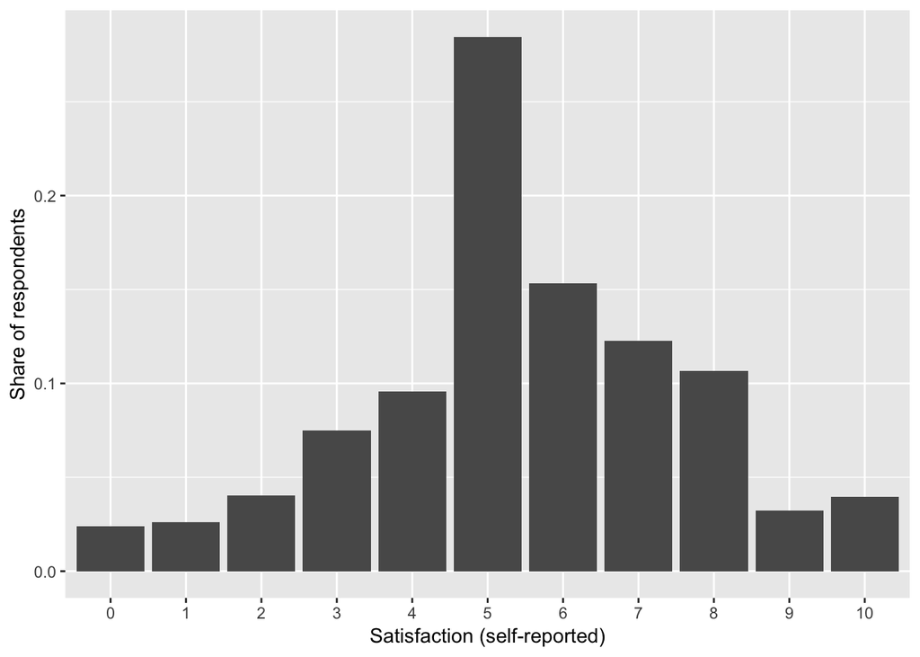

```r
ggplot(data = di, aes(x = factor(satis))) +
 geom_bar(aes(y = (..count..)/sum(..count..))) +
 scale_y_continuous() +
 xlab("Satisfaction (self-reported)") +
 ylab("Share of respondents")
```

### Variable name: `AGE`

- Source: Pew data set
- Values: Positive integers
- Coding: Respondent’s age in years at last birthday

```r
# summary(di$age)
descr(di$age, stats = c("mean", "sd", "min", "Q1", "med", "Q3", "max"), transpose = TRUE,
      omit.headings = TRUE, style = "rmarkdown")
```

|  | Mean | Std.Dev | Min | Q1 | Median | Q3 | Max |
| --- | --- | --- | --- | --- | --- | --- | --- |
| **age** | 39.63 | 12.17 | 21.00 | 29.00 | 39.00 | 49.00 | 70.00 |

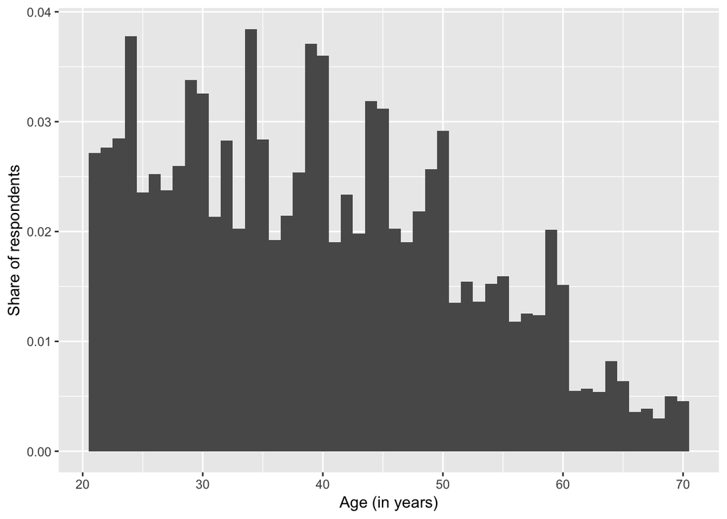

```r
ggplot(data = di, aes(x = age)) +
 geom_histogram(aes(y = (..count..)/sum(..count..)), binwidth = 1) +
 xlab("Age (in years)") +
 ylab("Share of respondents")
```

# Country-level analysis data set: `country-analysis.rds`

The country-level data set contains one observation for each of the 7 countries included in the individual-level data set. The country-level data set contains three variables: `CM_SATIS`, `exp`, and `inc`. Definitions, summary statistics and illustrations of the distributions of those three variables are shown below.

### Variable name: `CM_SATIS`

- Source: Pew data set
- Values: Real numbers from 0 through 10
- Definition: Mean value of `SATIS` for all respondents from the country

```r
# summary(dc$cm_satis)
descr(dc$cm_satis, stats = c("mean", "sd", "min", "Q1", "med", "Q3", "max"), transpose = TRUE,
      omit.headings = TRUE, style = "rmarkdown")
```

|  | Mean | Std.Dev | Min | Q1 | Median | Q3 | Max |
| --- | --- | --- | --- | --- | --- | --- | --- |
| **cm_satis** | 5.51 | 0.74 | 4.74 | 5.09 | 5.34 | 5.76 | 7.02 |

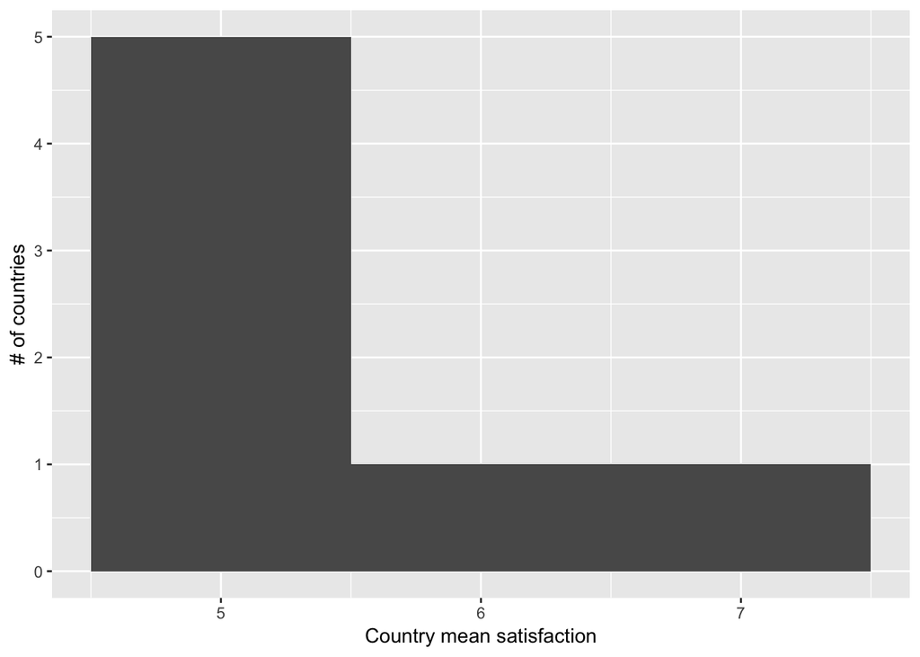

```r
ggplot(data = dc, aes(x = cm_satis)) +
  geom_histogram(binwidth = 1) +
  xlab("Country mean satisfaction") +
  ylab("# of countries")
```

### Variable name: `exp`

- Source: WDI
- Values: Positive real numbers
- Definition: General government consumption expenditure for 2002, as a percentage of GDP

```r
# summary(dc$exp)
descr(dc$exp, stats = c("mean", "sd", "min", "Q1", "med", "Q3", "max"), transpose = TRUE,
      omit.headings = TRUE, style = "rmarkdown")
```

|  | Mean | Std.Dev | Min | Q1 | Median | Q3 | Max |
| --- | --- | --- | --- | --- | --- | --- | --- |
| **exp** | 14.06 | 5.48 | 6.82 | 8.72 | 15.04 | 17.95 | 22.69 |

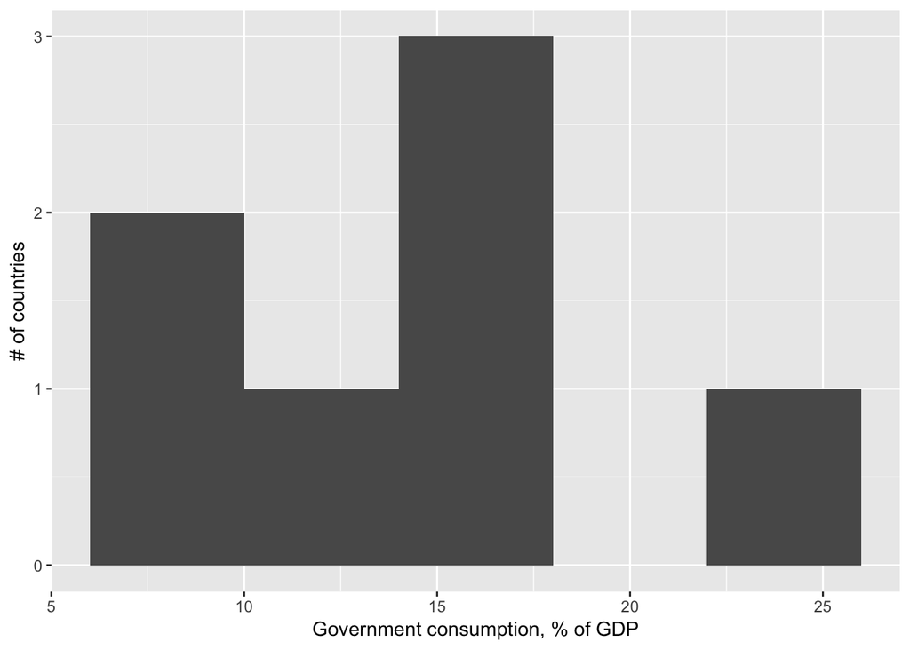

```r
ggplot(data = dc, aes(x = exp)) +
  geom_histogram(binwidth = 4) +
  xlab("Government consumption, % of GDP") +
  ylab("# of countries")
```

### Variable name: `inc`

- Source: WDI
- Values: Positive real numbers
- Definition: Income per capita for 2002, current US dollars

```r
# summary(dc$inc)
descr(dc$inc, stats = c("mean", "sd", "min", "Q1", "med", "Q3", "max"), transpose = TRUE,
      omit.headings = TRUE, style = "rmarkdown")
```

|  | Mean | Std.Dev | Min | Q1 | Median | Q3 | Max |
| --- | --- | --- | --- | --- | --- | --- | --- |
| **inc** | 6489.39 | 13985.05 | 466.20 | 499.86 | 1148.51 | 2375.06 | 38166.04 |

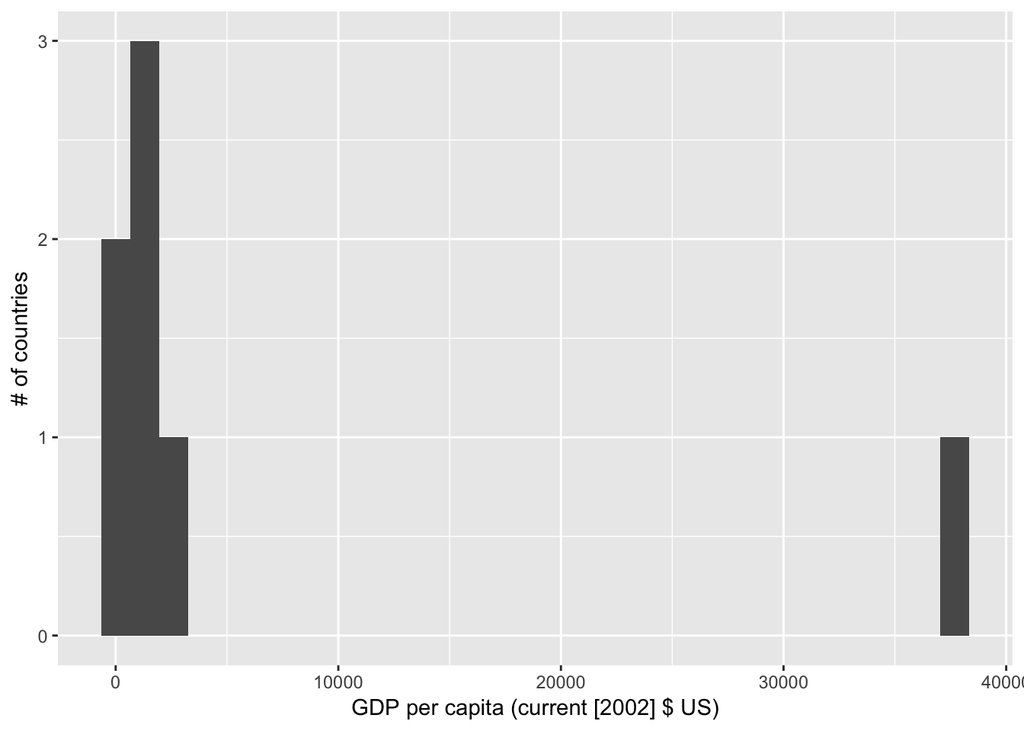

```r
ggplot(data = dc, aes(x = inc)) +
  geom_histogram() +
  xlab("GDP per capita (current [2002] $ US)") +
  ylab("# of countries")
```